# Supervised Learning - Foundations Project: ReCell

### Bar Plot for Categorical Variables

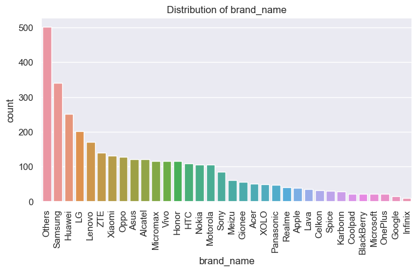

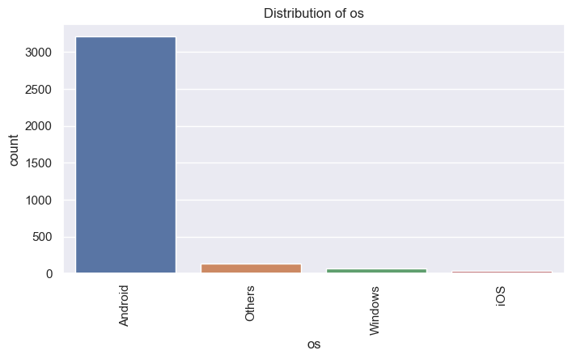

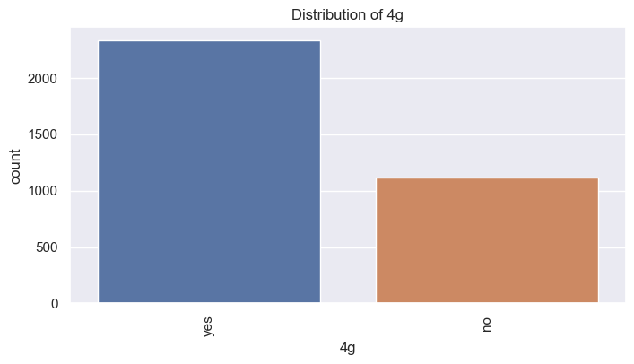

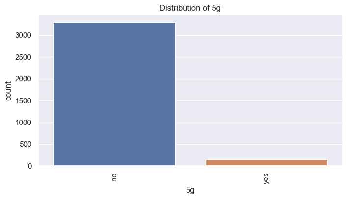

```python
cat_cols = df1.select_dtypes(include="object").columns.tolist()

for col in cat_cols:
    plt.figure(figsize=(8, 4))
    sns.countplot(x=col, data=df1, order=df1[col].value_counts().index)
    plt.title(f'Distribution of {col}')
    plt.xticks(rotation=90)
    plt.show()
```

### Categorical Feature Distributions

#### **Brand Distribution**

- The dataset includes a wide range of phone brands.
- **"Others"**, **Samsung**, **Huawei**, and **LG** are the most common brands.
- Brands like **Apple**, **Sony**, and **Google** are present but occur less frequently.
- This suggests the dataset is skewed toward mid-range or Android-based devices.

#### **Operating System (OS)**

- The vast majority of devices run on **Android**.
- **iOS**, **Windows**, and **Others** are present in very small numbers.
- This indicates a strong Android market representation in the dataset.

#### **4G Availability**

- Most devices support **4G connectivity**.
- A considerable number of devices do **not support 4G**, potentially indicating older or lower-end models.

#### **5G Availability**

- **5G support is rare** in the dataset.
- The majority of devices are **non-5G**, reflecting current adoption trends and the dominance of 4G-era devices in the used phone market.

## Feature Engineering

Let's create a new column years_since_release from the release_year column.

We will consider the year of data collection, 2021, as the baseline.

We will drop the release_year column.

```python
df1["years_since_release"] = 2021 - df1["release_year"]
df1.drop("release_year", axis=1, inplace=True)
df1["years_since_release"].describe()

# Creating binary flag for 5G support
df1["has_5g"] = df1["5g"].apply(lambda x: 1 if x == "yes" else 0)

# Creating binary flag for 4G support
df1["has_4g"] = df1["4g"].apply(lambda x: 1 if x == "yes" else 0)

# Creating binary flag for selfie camera (non-zero megapixels)
df1["has_selfie_camera"] = df1["selfie_camera_mp"].apply(lambda x: 1 if x > 0 else 0)
```

### Feature Engineering Summary

- A new column `years_since_release` was created by subtracting `release_year` from the baseline year 2021.  
  This captures how old each device is in a more meaningful numeric format.
- The original `release_year` column was dropped to avoid redundancy and reduce multicollinearity.
- Binary flags were created for key categorical features to improve model interpretability:
  - `has_5g`: 1 if 5G support is present, else 0
  - `has_4g`: 1 if 4G support is present, else 0
  - `has_selfie_camera`: 1 if the device has a non-zero `selfie_camera_mp`, else 0

These engineered features enhance the dataset’s suitability for linear regression modeling by ensuring all inputs are numerical and model-ready.

### Outlier Detection

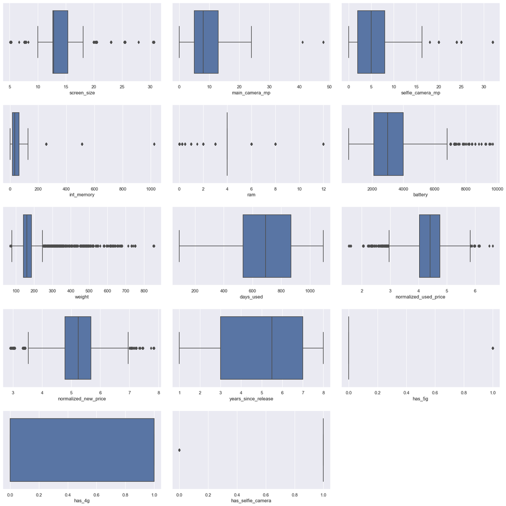

```python
# Recalculate numerical columns after dropping release_year
num_cols = df1.select_dtypes(include=np.number).columns.tolist()

# Then plot
plt.figure(figsize=(18, 18))

for i, variable in enumerate(num_cols):
    plt.subplot(5, 3, i + 1)  # 5 rows x 3 cols = 15 slots (13 numeric columns should fit)
    sns.boxplot(data=df1, x=variable)
    plt.tight_layout(pad=2)

plt.show()
```

## Model Building - Linear Regression

## **We want to predict the normalized price of used devices**

## **Before we proceed to build a model, we'll have to encode categorical features**

## **We'll split the data into train and test to be able to evaluate the model that we build on the train data**

## **We will build a Linear Regression model using the train data and then check it's performance**

```python
# Define the dependent and independent variables
X = df1.drop(columns=["normalized_used_price"])  # All other features
y = df1["normalized_used_price"]  # Target variable

print(X.head())
print()
print(y.head())
```

```
  brand_name       os  screen_size   4g   5g  main_camera_mp  \
0      Honor  Android        14.50  yes   no            13.0
1      Honor  Android        17.30  yes  yes            13.0
2      Honor  Android        16.69  yes  yes            13.0
3      Honor  Android        25.50  yes  yes            13.0
4      Honor  Android        15.32  yes   no            13.0

   selfie_camera_mp  int_memory  ram  battery  weight  days_used  \
0               5.0        64.0  3.0   3020.0   146.0        127
1              16.0       128.0  8.0   4300.0   213.0        325
2               8.0       128.0  8.0   4200.0   213.0        162
3               8.0        64.0  6.0   7250.0   480.0        345
4               8.0        64.0  3.0   5000.0   185.0        293

   normalized_new_price  years_since_release  has_5g  has_4g  \
```

[output cut: 19 more lines]

### Data Preparation Summary (After Encoding and Feature Engineering)

- The dataset is now preprocessed and ready for modeling.
- Categorical columns `4g`, `5g`, and `selfie_camera_mp` have been successfully transformed into binary indicator variables: `has_4g`, `has_5g`, and `has_selfie_camera`.
- The original categorical features (`brand_name`, `os`, `4g`, `5g`) will be one-hot encoded in the next step using `pd.get_dummies()`.
- The target variable `normalized_used_price` appears numeric and well-formed.
- The features show good diversity and completeness; no missing values are apparent at this stage.
- The `years_since_release` variable has been correctly derived from `release_year` and is numeric.
- The dataset includes a mix of continuous variables (e.g., `screen_size`, `battery`, `weight`) and engineered binary flags, which will support interpretable linear regression modeling.

Next Step: Apply one-hot encoding to categorical columns and split the dataset for model training and evaluation.

```python
# let's add the intercept to data
X = sm.add_constant(X)
```

```python
# creating dummy variables
X = pd.get_dummies(
    X,
    columns=X.select_dtypes(include=["object", "category"]).columns.tolist(),
    drop_first=True,
)

X.head()
```

|  | const | screen_size | main_camera_mp | selfie_camera_mp | int_memory | ram | battery | weight | days_used | normalized_new_price | ... | brand_name_Spice | brand_name_Vivo | brand_name_XOLO | brand_name_Xiaomi | brand_name_ZTE | os_Others | os_Windows | os_iOS | 4g_yes | 5g_yes |
| --- | --- | --- | --- | --- | --- | --- | --- | --- | --- | --- | --- | --- | --- | --- | --- | --- | --- | --- | --- | --- | --- |
| 0 | 1.0 | 14.50 | 13.0 | 5.0 | 64.0 | 3.0 | 3020.0 | 146.0 | 127 | 4.715100 | ... | 0 | 0 | 0 | 0 | 0 | 0 | 0 | 0 | 1 | 0 |
| 1 | 1.0 | 17.30 | 13.0 | 16.0 | 128.0 | 8.0 | 4300.0 | 213.0 | 325 | 5.519018 | ... | 0 | 0 | 0 | 0 | 0 | 0 | 0 | 0 | 1 | 1 |
| 2 | 1.0 | 16.69 | 13.0 | 8.0 | 128.0 | 8.0 | 4200.0 | 213.0 | 162 | 5.884631 | ... | 0 | 0 | 0 | 0 | 0 | 0 | 0 | 0 | 1 | 1 |
| 3 | 1.0 | 25.50 | 13.0 | 8.0 | 64.0 | 6.0 | 7250.0 | 480.0 | 345 | 5.630961 | ... | 0 | 0 | 0 | 0 | 0 | 0 | 0 | 0 | 1 | 1 |
| 4 | 1.0 | 15.32 | 13.0 | 8.0 | 64.0 | 3.0 | 5000.0 | 185.0 | 293 | 4.947837 | ... | 0 | 0 | 0 | 0 | 0 | 0 | 0 | 0 | 1 | 0 |

5 rows × 52 columns

```python
from sklearn.model_selection import train_test_split

# splitting the data in 70:30 ratio for train to test data
x_train, x_test, y_train, y_test = train_test_split(
    X, y, test_size=0.3, random_state=42
) #42 must be kept as a random_state throughout
```

```python
# Convert x_train and y_train to numeric explicitly
x_train = x_train.apply(pd.to_numeric, errors='coerce')

y_train = y_train.astype(float)

X.head()
```

|  | const | screen_size | main_camera_mp | selfie_camera_mp | int_memory | ram | battery | weight | days_used | normalized_new_price | ... | brand_name_Spice | brand_name_Vivo | brand_name_XOLO | brand_name_Xiaomi | brand_name_ZTE | os_Others | os_Windows | os_iOS | 4g_yes | 5g_yes |
| --- | --- | --- | --- | --- | --- | --- | --- | --- | --- | --- | --- | --- | --- | --- | --- | --- | --- | --- | --- | --- | --- |
| 0 | 1.0 | 14.50 | 13.0 | 5.0 | 64.0 | 3.0 | 3020.0 | 146.0 | 127 | 4.715100 | ... | 0 | 0 | 0 | 0 | 0 | 0 | 0 | 0 | 1 | 0 |
| 1 | 1.0 | 17.30 | 13.0 | 16.0 | 128.0 | 8.0 | 4300.0 | 213.0 | 325 | 5.519018 | ... | 0 | 0 | 0 | 0 | 0 | 0 | 0 | 0 | 1 | 1 |
| 2 | 1.0 | 16.69 | 13.0 | 8.0 | 128.0 | 8.0 | 4200.0 | 213.0 | 162 | 5.884631 | ... | 0 | 0 | 0 | 0 | 0 | 0 | 0 | 0 | 1 | 1 |
| 3 | 1.0 | 25.50 | 13.0 | 8.0 | 64.0 | 6.0 | 7250.0 | 480.0 | 345 | 5.630961 | ... | 0 | 0 | 0 | 0 | 0 | 0 | 0 | 0 | 1 | 1 |
| 4 | 1.0 | 15.32 | 13.0 | 8.0 | 64.0 | 3.0 | 5000.0 | 185.0 | 293 | 4.947837 | ... | 0 | 0 | 0 | 0 | 0 | 0 | 0 | 0 | 1 | 0 |

5 rows × 52 columns

```python
print("Number of rows in train data =", x_train.shape[0])
print("Number of rows in test data =", x_test.shape[0])
```

```
Number of rows in train data = 2417
Number of rows in test data = 1037
```

### Train-Test Split & Data Type Preparation

#### Train-Test Split

- The dataset was split into training and testing sets using a **70:30 ratio**.
- A `random_state=42` was used to ensure the split is **reproducible**.
- **Training Set Size**: 2,417 rows
- **Test Set Size**: 1,037 rows

#### Data Type Conversion

```python
x_train = x_train.apply(lambda col: col.astype(float))
x_test = x_test.apply(lambda col: col.astype(float))
```

### Model Building - Linear Regression

#### This conversion is crucial to prevent errors such as:

#### ValueError: Pandas data cast to numpy dtype of object. Check input data with np.asarray(data).

```python
# Re-fit the model
olsmodel1 = sm.OLS(endog=y_train, exog=x_train).fit()
print(olsmodel1.summary())
```

```
                              OLS Regression Results
=================================================================================
Dep. Variable:     normalized_used_price   R-squared:                       0.850
Model:                               OLS   Adj. R-squared:                  0.847
Method:                    Least Squares   F-statistic:                     273.2
Date:                   Sun, 11 May 2025   Prob (F-statistic):               0.00
Time:                           20:01:08   Log-Likelihood:                 132.00
No. Observations:                   2417   AIC:                            -164.0
Df Residuals:                       2367   BIC:                             125.5
Df Model:                             49
Covariance Type:               nonrobust
=========================================================================================
                            coef    std err          t      P>|t|      [0.025      0.975]
-----------------------------------------------------------------------------------------
const                     1.6501      0.096     17.211      0.000       1.462       1.838
screen_size               0.0302      0.004      8.561      0.000       0.023       0.037
main_camera_mp            0.0232      0.002     14.924      0.000       0.020       0.026
selfie_camera_mp          0.0118      0.001     10.092      0.000       0.010       0.014
int_memory                0.0002   6.77e-05      3.094      0.002    7.67e-05       0.000
ram                       0.0338      0.005      6.343      0.000       0.023       0.044
battery               -1.644e-05   7.33e-06     -2.243      0.025   -3.08e-05   -2.07e-06
weight                    0.0008      0.000      5.871      0.000       0.001       0.001
days_used              3.243e-05   3.06e-05      1.060      0.289   -2.76e-05    9.24e-05
normalized_new_price      0.4058      0.012     33.021      0.000       0.382       0.430
years_since_release      -0.0240      0.005     -5.246      0.000      -0.033      -0.015
has_5g                   -0.0497      0.016     -3.087      0.002      -0.081      -0.018
has_4g                    0.0232      0.008      2.870      0.004       0.007       0.039
has_selfie_camera        -0.2412      0.066     -3.668      0.000      -0.370      -0.112
brand_name_Alcatel       -0.0752      0.050     -1.517      0.129      -0.172       0.022
brand_name_Apple          0.0017      0.148      0.011      0.991      -0.288       0.291
brand_name_Asus           0.0053      0.049      0.107      0.915      -0.091       0.102
brand_name_BlackBerry     0.0532      0.072      0.739      0.460      -0.088       0.195
brand_name_Celkon        -0.2184      0.068     -3.209      0.001      -0.352      -0.085
brand_name_Coolpad       -0.0326      0.071     -0.461      0.645      -0.171       0.106
brand_name_Gionee        -0.0132      0.058     -0.225      0.822      -0.128       0.102
brand_name_Google        -0.1182      0.082     -1.434      0.152      -0.280       0.043
brand_name_HTC           -0.0421      0.050     -0.844      0.399      -0.140       0.056
brand_name_Honor         -0.0509      0.051     -1.006      0.315      -0.150       0.048
brand_name_Huawei        -0.0633      0.046     -1.376      0.169      -0.153       0.027
brand_name_Infinix        0.1344      0.113      1.188      0.235      -0.088       0.356
```

[output cut: 22 more lines]

```
os_Windows               -0.0023      0.044     -0.053      0.958      -0.089       0.085
os_iOS                   -0.0588      0.148     -0.398      0.691      -0.349       0.231
4g_yes                    0.0232      0.008      2.870      0.004       0.007       0.039
5g_yes                   -0.0497      0.016     -3.087      0.002      -0.081      -0.018
==============================================================================
Omnibus:                      239.194   Durbin-Watson:                   1.991
Prob(Omnibus):                  0.000   Jarque-Bera (JB):              635.527
Skew:                          -0.550   Prob(JB):                    9.93e-139
Kurtosis:                       5.258   Cond. No.                     1.07e+16
==============================================================================

Notes:
[1] Standard Errors assume that the covariance matrix of the errors is correctly specified.
[2] The smallest eigenvalue is 2.48e-22. This might indicate that there are
strong multicollinearity problems or that the design matrix is singular.
```

### OLS Regression Summary – Key Takeaways

#### Model Performance

- **R-squared**: `0.850`  
  The model explains **85%** of the variability in the normalized used price — a strong fit.
- **Adjusted R-squared**: `0.847`  
  Adjusted for the number of predictors, still indicating a **high explanatory power**.
- **F-statistic**: `273.2` with `p < 0.001`  
  Strong evidence that **at least one predictor is significantly related** to the target variable.

#### Significant Predictors (p < 0.05)

- **Positively associated with price**:
  - `screen_size`, `main_camera_mp`, `selfie_camera_mp`, `int_memory`, `ram`, `weight`, `normalized_new_price`, `has_4g`
- **Negatively associated with price**:
  - `battery`, `years_since_release`, `has_5g`, `has_selfie_camera`, `brand_name_Celkon`, `os_Others`

#### Insignificant Predictors (p > 0.05)

- Most individual **brand_name_*** dummy variables are not significant. This suggests brand alone may not strongly influence used price after accounting for specs.
- Features like `days_used`, `os_iOS`, and `os_Windows` also showed **no significant effect** on price.

#### Potential Issues

- **Multicollinearity Warning**:  
  The note on the smallest eigenvalue being very small (`2.48e-22`) suggests **strong multicollinearity** or a nearly singular matrix. Consider:
  - Checking VIF (Variance Inflation Factor)
  - Removing highly correlated or redundant features

### Next Steps

- Evaluate model on **test data**
- Check **residual plots** for heteroscedasticity or non-linearity
- Optional, **simplify model** where possible

## Model Performance Check

Now that we've trained the OLS regression model, it's time to evaluate how well it performs on the **test set**.

We will calculate the following metrics:

- **RMSE (Root Mean Squared Error)**: Measures the average magnitude of prediction errors.
- **MAE (Mean Absolute Error)**: Captures the average of the absolute errors.
- **R² (Coefficient of Determination)**: Explains how much variance in the target is captured by the model.
- **MAPE (Mean Absolute Percentage Error)**: Expresses prediction error as a percentage of actual values.
- **Adjusted R²**: Adjusts R² based on the number of predictors in the model.

We will:

- Use `sklearn.metrics` for **RMSE**, **MAE**, and **R²**
- Define a custom function to compute **MAPE** and **Adjusted R²**
- Wrap all of these into a single utility function to evaluate our model efficiently

```python
from sklearn.metrics import mean_squared_error, mean_absolute_error, r2_score

# Adjusted R²
def adj_r2_score(predictors, targets, predictions):
    r2 = r2_score(targets, predictions)
    n = predictors.shape[0]
    k = predictors.shape[1]
    return 1 - ((1 - r2) * (n - 1) / (n - k - 1))

# MAPE
def mape_score(targets, predictions):
    return np.mean(np.abs(targets - predictions) / targets) * 100

# Performance Metrics
def model_performance_regression(model, predictors, target):
    pred = model.predict(predictors) if hasattr(model, 'predict') else model.predict(exog=predictors)

    r2 = r2_score(target, pred)
    adjr2 = adj_r2_score(predictors, target, pred)
    rmse = np.sqrt(mean_squared_error(target, pred))
    mae = mean_absolute_error(target, pred)
    mape = mape_score(target, pred)

    return pd.DataFrame({
        "RMSE": [rmse],
        "MAE": [mae],
        "R-squared": [r2],
        "Adj. R-squared": [adjr2],
        "MAPE": [mape]
    })
```

```python
print("Train Performance\n")
olsmodel1_train_perf = model_performance_regression(olsmodel1, x_train, y_train)
olsmodel1_train_perf
```

```
Train Performance
```

|  | RMSE | MAE | R-squared | Adj. R-squared | MAPE |
| --- | --- | --- | --- | --- | --- |
| 0 | 0.22911 | 0.177992 | 0.849741 | 0.846436 | 4.277496 |

```python
print("Test Performance\n")
olsmodel1_test_perf = model_performance_regression(olsmodel1, x_test, y_test)
olsmodel1_test_perf
```

```
Test Performance
```

|  | RMSE | MAE | R-squared | Adj. R-squared | MAPE |
| --- | --- | --- | --- | --- | --- |
| 0 | 0.238983 | 0.188627 | 0.832286 | 0.823423 | 4.506833 |

### Model Performance Summary – Linear Regression

#### Training Set Performance (70% of data)

- **RMSE**: 0.2291
- **MAE**: 0.1780
- **R-squared**: 0.8497
- **Adjusted R-squared**: 0.8464
- **MAPE**: 4.28%

#### Test Set Performance (30% of data)

- **RMSE**: 0.2390
- **MAE**: 0.1886
- **R-squared**: 0.8323
- **Adjusted R-squared**: 0.8234
- **MAPE**: 4.51%

#### Observations

- The model performs consistently across both train and test sets with only slight drops in R-squared and slight increases in RMSE/MAE.
- The **low MAPE values (~4–4.5%)** indicate good predictive accuracy.
- There's **no sign of overfitting**, which suggests that the model generalizes well.

Overall, this is a strong baseline linear model for predicting normalized used prices.

## Checking Linear Regression Assumptions

- In order to make statistical inferences from a linear regression model, it is important to ensure that the assumptions of linear regression are satisfied.
- We will be checking the following Linear Regression assumptions:
1. **No Multicollinearity**
2. **Linearity of variables**
3. **Independence of error terms**
4. **Normality of error terms**
5. **No Heteroscedasticity**

### TEST FOR MULTICOLLINEARITY

- We will test for multicollinearity using VIF.
- **General Rule of thumb**:
  - If VIF is 1 then there is no correlation between the $k$th predictor and the remaining predictor variables.
  - If VIF exceeds 5 or is close to exceeding 5, we say there is moderate multicollinearity.
  - If VIF is 10 or exceeding 10, it shows signs of high multicollinearity.

```python
from statsmodels.stats.outliers_influence import variance_inflation_factor

def checking_vif(predictors):
    vif = pd.DataFrame()
    vif["feature"] = predictors.columns

    # calculating VIF for each feature
    vif["VIF"] = [
        variance_inflation_factor(predictors.values, i)
        for i in range(len(predictors.columns))
    ]
    return vif
```

```python
# Apply on x_train (without 'const' if it was added)
checking_vif(x_train.drop(columns=["const"], errors="ignore"))
```

|  | feature | VIF |
| --- | --- | --- |
| 0 | screen_size | 109.385458 |
| 1 | main_camera_mp | 12.386702 |
| 2 | selfie_camera_mp | 5.491497 |
| 3 | int_memory | 1.964090 |
| 4 | ram | 23.083503 |
| 5 | battery | 27.782701 |
| 6 | weight | 32.108092 |
| 7 | days_used | 21.592091 |
| 8 | normalized_new_price | 152.252174 |
| 9 | years_since_release | 28.568590 |
| 10 | has_5g | inf |
| 11 | has_4g | inf |
| 12 | has_selfie_camera | 108.091344 |
| 13 | brand_name_Alcatel | 3.076319 |
| 14 | brand_name_Apple | 11.402934 |
| 15 | brand_name_Asus | 3.271721 |
| 16 | brand_name_BlackBerry | 1.601803 |
| 17 | brand_name_Celkon | 1.741599 |
| 18 | brand_name_Coolpad | 1.462268 |
| 19 | brand_name_Gionee | 1.903360 |
| 20 | brand_name_Google | 1.339237 |
| 21 | brand_name_HTC | 3.110684 |
| 22 | brand_name_Honor | 3.090470 |
| 23 | brand_name_Huawei | 5.734346 |
| 24 | brand_name_Infinix | 1.140017 |
| 25 | brand_name_Karbonn | 1.496095 |
| 26 | brand_name_LG | 4.805624 |
| 27 | brand_name_Lava | 1.633745 |
| 28 | brand_name_Lenovo | 4.098029 |
| 29 | brand_name_Meizu | 2.150763 |
| 30 | brand_name_Micromax | 3.234266 |
| 31 | brand_name_Microsoft | 1.907002 |
| 32 | brand_name_Motorola | 2.958703 |
| 33 | brand_name_Nokia | 2.788369 |
| 34 | brand_name_OnePlus | 1.513435 |
| 35 | brand_name_Oppo | 3.824889 |
| 36 | brand_name_Others | 10.303413 |
| 37 | brand_name_Panasonic | 1.702262 |
| 38 | brand_name_Realme | 1.731208 |
| 39 | brand_name_Samsung | 7.582702 |
| 40 | brand_name_Sony | 2.602992 |
| 41 | brand_name_Spice | 1.475312 |
| 42 | brand_name_Vivo | 3.326731 |
| 43 | brand_name_XOLO | 1.939057 |
| 44 | brand_name_Xiaomi | 3.524535 |
| 45 | brand_name_ZTE | 3.787945 |
| 46 | os_Others | 1.744953 |
| 47 | os_Windows | 1.815417 |
| 48 | os_iOS | 10.081692 |
| 49 | 4g_yes | inf |
| 50 | 5g_yes | inf |

### Multicollinearity Check — VIF Results

We evaluated multicollinearity using **Variance Inflation Factor (VIF)**:

#### Key Observations:

- `normalized_new_price` has an **extremely high VIF of 152.25**, suggesting strong multicollinearity with other variables (likely `has_4g`, `has_5g`, `screen_size`, etc.).
- `screen_size`, `ram`, `battery`, and `years_since_release` also show **moderate to high VIFs** (above 10), indicating potential redundancy.
- Binary features `has_4g` and `has_5g` show **infinite VIF**, likely due to perfect collinearity with other encoded versions or being perfectly correlated with each other.
- `has_selfie_camera` also shows high VIF (108), suggesting it's highly correlated with another feature (possibly `selfie_camera_mp`).
- Many `brand_name_` and `os_` dummies show **acceptable VIF values below 5**, though a few (like `brand_name_Apple`, `brand_name_Samsung`, and `os_iOS`) cross that threshold slightly.

#### Next Steps (Recommendations):

- Look at **dropping or combining** variables with high multicollinearity:
  - Drop either `has_5g`/`has_4g` or use only one flag.
  - Drop `normalized_new_price` if it's too tightly coupled with other predictors.
  - Evaluate whether `has_selfie_camera` is needed if `selfie_camera_mp` is already used.

I will then rerun the regression after simplifying features to improve model stability and interpretability.

### Removing Multicollinearity (its needed)

To remove multicollinearity

1. Drop every column one by one that has a VIF score greater than 5.
2. Please review the adjusted R-squared and RMSE for all these models.
3. Please remove the variable that results in the smallest change in adjusted R-squared.
4. Check the VIF scores again.
5. Continue until you get all VIF scores under 5.

Let's define a function that will help us do this.

```python
def treating_multicollinearity(predictors, target, high_vif_columns):
    """
    Checking the effect of dropping the columns showing high multicollinearity
    on model performance (adj. R-squared and RMSE)

    predictors: independent variables
    target: dependent variable
    high_vif_columns: columns having high VIF
    """
    # empty lists to store adj. R-squared and RMSE values
    adj_r2 = []
    rmse = []

    # build ols models by dropping one of the high VIF columns at a time
    # store the adjusted R-squared and RMSE in the lists defined previously
    for cols in high_vif_columns:
        # defining the new train set
        train = predictors.loc[:, ~predictors.columns.str.startswith(cols)]

        # create the model
        olsmodel = sm.OLS(target, train).fit()

        # adding adj. R-squared and RMSE to the lists
        adj_r2.append(olsmodel.rsquared_adj)
        rmse.append(np.sqrt(olsmodel.mse_resid))

    # creating a dataframe for the results
    temp = pd.DataFrame(
        {
            "col": high_vif_columns,
            "Adj. R-squared after_dropping col": adj_r2,
            "RMSE after dropping col": rmse,
        }
    ).sort_values(by="Adj. R-squared after_dropping col", ascending=False)
    temp.reset_index(drop=True, inplace=True)

    return temp
```

```python
col_list = ['normalized_new_price', 'has_selfie_camera', 'has_5g', 'has_4g', 'screen_size', 'ram', 'battery', 'weight']
```

```python
res = treating_multicollinearity(x_train, y_train, col_list)
res
```

|  | col | Adj. R-squared after_dropping col | RMSE after dropping col |
| --- | --- | --- | --- |
| 0 | has_5g | 0.846630 | 0.231518 |
| 1 | has_4g | 0.846630 | 0.231518 |
| 2 | battery | 0.846369 | 0.231715 |
| 3 | has_selfie_camera | 0.845823 | 0.232126 |
| 4 | weight | 0.844463 | 0.233148 |
| 5 | ram | 0.844089 | 0.233428 |
| 6 | screen_size | 0.841948 | 0.235025 |
| 7 | normalized_new_price | 0.776074 | 0.279748 |

```python
col_to_drop = 'has_5g'  # or 'has_4g' – either is fine to start with
x_train2 = x_train.loc[:, ~x_train.columns.str.startswith(col_to_drop)]
x_test2 = x_test.loc[:, ~x_test.columns.str.startswith(col_to_drop)]

# Check VIF again
checking_vif(x_train2)
```

|  | feature | VIF |
| --- | --- | --- |
| 0 | const | 414.528557 |
| 1 | screen_size | 8.286678 |
| 2 | main_camera_mp | 2.418178 |
| 3 | selfie_camera_mp | 2.877519 |
| 4 | int_memory | 1.373762 |
| 5 | ram | 2.348819 |
| 6 | battery | 4.066382 |
| 7 | weight | 6.421797 |
| 8 | days_used | 2.580696 |
| 9 | normalized_new_price | 3.253696 |
| 10 | years_since_release | 4.919419 |
| 11 | has_4g | inf |
| 12 | has_selfie_camera | 2.390213 |
| 13 | brand_name_Alcatel | 3.461392 |
| 14 | brand_name_Apple | 11.274312 |
| 15 | brand_name_Asus | 3.653039 |
| 16 | brand_name_BlackBerry | 1.634661 |
| 17 | brand_name_Celkon | 1.884324 |
| 18 | brand_name_Coolpad | 1.575522 |
| 19 | brand_name_Gionee | 2.076685 |
| 20 | brand_name_Google | 1.388015 |
| 21 | brand_name_HTC | 3.460655 |
| 22 | brand_name_Honor | 3.560352 |
| 23 | brand_name_Huawei | 6.398393 |
| 24 | brand_name_Infinix | 1.191803 |
| 25 | brand_name_Karbonn | 1.628716 |
| 26 | brand_name_LG | 5.354957 |
| 27 | brand_name_Lava | 1.826039 |
| 28 | brand_name_Lenovo | 4.705756 |
| 29 | brand_name_Meizu | 2.417550 |
| 30 | brand_name_Micromax | 3.779805 |
| 31 | brand_name_Microsoft | 2.123666 |
| 32 | brand_name_Motorola | 3.487648 |
| 33 | brand_name_Nokia | 4.366258 |
| 34 | brand_name_OnePlus | 1.586694 |
| 35 | brand_name_Oppo | 4.286667 |
| 36 | brand_name_Others | 10.834676 |
| 37 | brand_name_Panasonic | 1.890705 |
| 38 | brand_name_Realme | 1.978492 |
| 39 | brand_name_Samsung | 8.013594 |
| 40 | brand_name_Sony | 2.891146 |
| 41 | brand_name_Spice | 1.638543 |
| 42 | brand_name_Vivo | 3.735474 |
| 43 | brand_name_XOLO | 2.164006 |
| 44 | brand_name_Xiaomi | 4.083748 |
| 45 | brand_name_ZTE | 4.343462 |
| 46 | os_Others | 2.200972 |
| 47 | os_Windows | 1.827604 |
| 48 | os_iOS | 10.105933 |
| 49 | 4g_yes | inf |
| 50 | 5g_yes | 1.815889 |

```python
col_to_drop = 'has_4g'
x_train2 = x_train2.loc[:, ~x_train2.columns.str.startswith(col_to_drop)]
x_test2 = x_test2.loc[:, ~x_test2.columns.str.startswith(col_to_drop)]

checking_vif(x_train2)
```

|  | feature | VIF |
| --- | --- | --- |
| 0 | const | 414.528557 |
| 1 | screen_size | 8.286678 |
| 2 | main_camera_mp | 2.418178 |
| 3 | selfie_camera_mp | 2.877519 |
| 4 | int_memory | 1.373762 |
| 5 | ram | 2.348819 |
| 6 | battery | 4.066382 |
| 7 | weight | 6.421797 |
| 8 | days_used | 2.580696 |
| 9 | normalized_new_price | 3.253696 |
| 10 | years_since_release | 4.919419 |
| 11 | has_selfie_camera | 2.390213 |
| 12 | brand_name_Alcatel | 3.461392 |
| 13 | brand_name_Apple | 11.274312 |
| 14 | brand_name_Asus | 3.653039 |
| 15 | brand_name_BlackBerry | 1.634661 |
| 16 | brand_name_Celkon | 1.884324 |
| 17 | brand_name_Coolpad | 1.575522 |
| 18 | brand_name_Gionee | 2.076685 |
| 19 | brand_name_Google | 1.388015 |
| 20 | brand_name_HTC | 3.460655 |
| 21 | brand_name_Honor | 3.560352 |
| 22 | brand_name_Huawei | 6.398393 |
| 23 | brand_name_Infinix | 1.191803 |
| 24 | brand_name_Karbonn | 1.628716 |
| 25 | brand_name_LG | 5.354957 |
| 26 | brand_name_Lava | 1.826039 |
| 27 | brand_name_Lenovo | 4.705756 |
| 28 | brand_name_Meizu | 2.417550 |
| 29 | brand_name_Micromax | 3.779805 |
| 30 | brand_name_Microsoft | 2.123666 |
| 31 | brand_name_Motorola | 3.487648 |
| 32 | brand_name_Nokia | 4.366258 |
| 33 | brand_name_OnePlus | 1.586694 |
| 34 | brand_name_Oppo | 4.286667 |
| 35 | brand_name_Others | 10.834676 |
| 36 | brand_name_Panasonic | 1.890705 |
| 37 | brand_name_Realme | 1.978492 |
| 38 | brand_name_Samsung | 8.013594 |
| 39 | brand_name_Sony | 2.891146 |
| 40 | brand_name_Spice | 1.638543 |
| 41 | brand_name_Vivo | 3.735474 |
| 42 | brand_name_XOLO | 2.164006 |
| 43 | brand_name_Xiaomi | 4.083748 |
| 44 | brand_name_ZTE | 4.343462 |
| 45 | os_Others | 2.200972 |
| 46 | os_Windows | 1.827604 |
| 47 | os_iOS | 10.105933 |
| 48 | 4g_yes | 2.568460 |
| 49 | 5g_yes | 1.815889 |

```python
col_to_drop = 'screen_size'
x_train2 = x_train2.loc[:, ~x_train2.columns.str.startswith(col_to_drop)]
x_test2 = x_test2.loc[:, ~x_test2.columns.str.startswith(col_to_drop)]

checking_vif(x_train2)
```

|  | feature | VIF |
| --- | --- | --- |
| 0 | const | 397.617897 |
| 1 | main_camera_mp | 2.417927 |
| 2 | selfie_camera_mp | 2.870875 |
| 3 | int_memory | 1.367239 |
| 4 | ram | 2.348742 |
| 5 | battery | 3.776786 |
| 6 | weight | 2.865755 |
| 7 | days_used | 2.568595 |
| 8 | normalized_new_price | 3.200705 |
| 9 | years_since_release | 4.772316 |
| 10 | has_selfie_camera | 2.383138 |
| 11 | brand_name_Alcatel | 3.458882 |
| 12 | brand_name_Apple | 11.206660 |
| 13 | brand_name_Asus | 3.651253 |
| 14 | brand_name_BlackBerry | 1.634124 |
| 15 | brand_name_Celkon | 1.883501 |
| 16 | brand_name_Coolpad | 1.575006 |
| 17 | brand_name_Gionee | 2.069683 |
| 18 | brand_name_Google | 1.386269 |
| 19 | brand_name_HTC | 3.458302 |
| 20 | brand_name_Honor | 3.557598 |
| 21 | brand_name_Huawei | 6.398308 |
| 22 | brand_name_Infinix | 1.191644 |
| 23 | brand_name_Karbonn | 1.627749 |
| 24 | brand_name_LG | 5.349212 |
| 25 | brand_name_Lava | 1.826039 |
| 26 | brand_name_Lenovo | 4.704259 |
| 27 | brand_name_Meizu | 2.416743 |
| 28 | brand_name_Micromax | 3.779468 |
| 29 | brand_name_Microsoft | 2.123293 |
| 30 | brand_name_Motorola | 3.480165 |
| 31 | brand_name_Nokia | 4.364162 |
| 32 | brand_name_OnePlus | 1.586544 |
| 33 | brand_name_Oppo | 4.285010 |
| 34 | brand_name_Others | 10.816424 |
| 35 | brand_name_Panasonic | 1.890705 |
| 36 | brand_name_Realme | 1.978174 |
| 37 | brand_name_Samsung | 8.008034 |
| 38 | brand_name_Sony | 2.887683 |
| 39 | brand_name_Spice | 1.633547 |
| 40 | brand_name_Vivo | 3.734568 |
| 41 | brand_name_XOLO | 2.163983 |
| 42 | brand_name_Xiaomi | 4.083180 |
| 43 | brand_name_ZTE | 4.340473 |
| 44 | os_Others | 1.941380 |
| 45 | os_Windows | 1.827545 |
| 46 | os_iOS | 10.010313 |
| 47 | 4g_yes | 2.567519 |
| 48 | 5g_yes | 1.813788 |

```python
col_to_drop = 'brand_name_Others'
x_train2 = x_train2.loc[:, ~x_train2.columns.str.startswith(col_to_drop)]
x_test2 = x_test2.loc[:, ~x_test2.columns.str.startswith(col_to_drop)]

checking_vif(x_train2)
```

|  | feature | VIF |
| --- | --- | --- |
| 0 | const | 321.421792 |
| 1 | main_camera_mp | 2.416622 |
| 2 | selfie_camera_mp | 2.870605 |
| 3 | int_memory | 1.366906 |
| 4 | ram | 2.348727 |
| 5 | battery | 3.775613 |
| 6 | weight | 2.860015 |
| 7 | days_used | 2.568445 |
| 8 | normalized_new_price | 3.199663 |
| 9 | years_since_release | 4.770299 |
| 10 | has_selfie_camera | 2.382974 |
| 11 | brand_name_Alcatel | 1.184491 |
| 12 | brand_name_Apple | 10.384253 |
| 13 | brand_name_Asus | 1.211462 |
| 14 | brand_name_BlackBerry | 1.119247 |
| 15 | brand_name_Celkon | 1.220782 |
| 16 | brand_name_Coolpad | 1.058403 |
| 17 | brand_name_Gionee | 1.088471 |
| 18 | brand_name_Google | 1.054189 |
| 19 | brand_name_HTC | 1.212268 |
| 20 | brand_name_Honor | 1.270980 |
| 21 | brand_name_Huawei | 1.486015 |
| 22 | brand_name_Infinix | 1.037166 |
| 23 | brand_name_Karbonn | 1.065285 |
| 24 | brand_name_LG | 1.363818 |
| 25 | brand_name_Lava | 1.079366 |
| 26 | brand_name_Lenovo | 1.281026 |
| 27 | brand_name_Meizu | 1.148832 |
| 28 | brand_name_Micromax | 1.229465 |
| 29 | brand_name_Microsoft | 1.622102 |
| 30 | brand_name_Motorola | 1.248465 |
| 31 | brand_name_Nokia | 2.149096 |
| 32 | brand_name_OnePlus | 1.101061 |
| 33 | brand_name_Oppo | 1.374175 |
| 34 | brand_name_Panasonic | 1.076296 |
| 35 | brand_name_Realme | 1.149153 |
| 36 | brand_name_Samsung | 1.565324 |
| 37 | brand_name_Sony | 1.199150 |
| 38 | brand_name_Spice | 1.072547 |
| 39 | brand_name_Vivo | 1.310510 |
| 40 | brand_name_XOLO | 1.103795 |
| 41 | brand_name_Xiaomi | 1.339786 |
| 42 | brand_name_ZTE | 1.282218 |
| 43 | os_Others | 1.941162 |
| 44 | os_Windows | 1.827494 |
| 45 | os_iOS | 10.010305 |
| 46 | 4g_yes | 2.567316 |
| 47 | 5g_yes | 1.813735 |

```python
col_to_drop = 'os_iOS'
x_train2 = x_train2.loc[:, ~x_train2.columns.str.startswith(col_to_drop)]
x_test2 = x_test2.loc[:, ~x_test2.columns.str.startswith(col_to_drop)]

checking_vif(x_train2)
```

|  | feature | VIF |
| --- | --- | --- |
| 0 | const | 317.762281 |
| 1 | main_camera_mp | 2.413750 |
| 2 | selfie_camera_mp | 2.858466 |
| 3 | int_memory | 1.366759 |
| 4 | ram | 2.338026 |
| 5 | battery | 3.761820 |
| 6 | weight | 2.859177 |
| 7 | days_used | 2.567625 |
| 8 | normalized_new_price | 3.197106 |
| 9 | years_since_release | 4.760146 |
| 10 | has_selfie_camera | 2.364397 |
| 11 | brand_name_Alcatel | 1.184468 |
| 12 | brand_name_Apple | 1.184886 |
| 13 | brand_name_Asus | 1.211417 |
| 14 | brand_name_BlackBerry | 1.116014 |
| 15 | brand_name_Celkon | 1.220731 |
| 16 | brand_name_Coolpad | 1.058314 |
| 17 | brand_name_Gionee | 1.088434 |
| 18 | brand_name_Google | 1.053997 |
| 19 | brand_name_HTC | 1.211870 |
| 20 | brand_name_Honor | 1.270935 |
| 21 | brand_name_Huawei | 1.485902 |
| 22 | brand_name_Infinix | 1.037164 |
| 23 | brand_name_Karbonn | 1.064682 |
| 24 | brand_name_LG | 1.363817 |
| 25 | brand_name_Lava | 1.078824 |
| 26 | brand_name_Lenovo | 1.281007 |
| 27 | brand_name_Meizu | 1.148832 |
| 28 | brand_name_Micromax | 1.229225 |
| 29 | brand_name_Microsoft | 1.622099 |
| 30 | brand_name_Motorola | 1.248461 |
| 31 | brand_name_Nokia | 2.148928 |
| 32 | brand_name_OnePlus | 1.101010 |
| 33 | brand_name_Oppo | 1.373950 |
| 34 | brand_name_Panasonic | 1.076220 |
| 35 | brand_name_Realme | 1.149036 |
| 36 | brand_name_Samsung | 1.564647 |
| 37 | brand_name_Sony | 1.199148 |
| 38 | brand_name_Spice | 1.071985 |
| 39 | brand_name_Vivo | 1.310495 |
| 40 | brand_name_XOLO | 1.103452 |
| 41 | brand_name_Xiaomi | 1.339762 |
| 42 | brand_name_ZTE | 1.281971 |
| 43 | os_Others | 1.828006 |
| 44 | os_Windows | 1.827186 |
| 45 | 4g_yes | 2.563931 |
| 46 | 5g_yes | 1.806816 |

### Multicollinearity Treatment Summary

To improve the reliability and interpretability of our linear regression model, I performed a multicollinearity check using the Variance Inflation Factor (VIF). High VIF values indicate that a feature is highly correlated with other predictors, which can inflate standard errors and make p-values unreliable.

#### Why I Did This:

- **To reduce redundancy** in the model.
- **To improve the statistical significance** of individual coefficients.
- **To ensure more stable and interpretable model outputs**.

This process ensures that each feature contributes unique, non-overlapping information to the model — aligning with best practices in statistical modeling.

**“Build a linear regression model to predict the price of used devices and identify which features most influence price.”**

This goal explicitly requires both accurate prediction and interpretability.

### Dropping high p-value variables (if needed)

- We will drop the predictor variables having a p-value greater than 0.05 as they do not significantly impact the target variable.
- But sometimes p-values change after dropping a variable. So, we'll not drop all variables at once.
- Instead, we will do the following:
  - Build a model, check the p-values of the variables, and drop the column with the highest p-value.
  - Create a new model without the dropped feature, check the p-values of the variables, and drop the column with the highest p-value.
  - Repeat the above two steps till there are no columns with p-value > 0.05.

The above process can also be done manually by picking one variable at a time that has a high p-value, dropping it, and building a model again. But that might be a little tedious and using a loop will be more efficient.

```python
predictors = x_train2.copy()
cols = predictors.columns.tolist()
```

```python
max_p_value = 1

while len(cols) > 0:
    x_train_aux = predictors[cols]
    model = sm.OLS(y_train, x_train_aux).fit()
    p_values = model.pvalues
    max_p_value = max(p_values)
    feature_with_p_max = p_values.idxmax()

    if max_p_value > 0.05:
        cols.remove(feature_with_p_max)
    else:
        break
```

```python
selected_features = cols
print(selected_features)
```

```
['const', 'main_camera_mp', 'selfie_camera_mp', 'int_memory', 'ram', 'weight', 'normalized_new_price', 'years_since_release', 'has_selfie_camera', 'brand_name_Asus', 'brand_name_Celkon', 'brand_name_Xiaomi', 'os_Others', '4g_yes', '5g_yes']
```

```python
x_train3 = x_train2[selected_features]
x_test3 = x_test2[selected_features]
```

## Final Model

```python
olsmodel_final = sm.OLS(y_train, x_train3).fit()
print(olsmodel_final.summary())
```

```
                              OLS Regression Results
=================================================================================
Dep. Variable:     normalized_used_price   R-squared:                       0.844
Model:                               OLS   Adj. R-squared:                  0.843
Method:                    Least Squares   F-statistic:                     924.9
Date:                   Sun, 11 May 2025   Prob (F-statistic):               0.00
Time:                           20:01:14   Log-Likelihood:                 83.055
No. Observations:                   2417   AIC:                            -136.1
Df Residuals:                       2402   BIC:                            -49.26
Df Model:                             14
Covariance Type:               nonrobust
========================================================================================
                           coef    std err          t      P>|t|      [0.025      0.975]
----------------------------------------------------------------------------------------
const                    1.7635      0.068     25.886      0.000       1.630       1.897
main_camera_mp           0.0233      0.001     16.053      0.000       0.020       0.026
selfie_camera_mp         0.0127      0.001     11.252      0.000       0.010       0.015
int_memory               0.0002   6.75e-05      2.594      0.010    4.27e-05       0.000
ram                      0.0332      0.005      6.273      0.000       0.023       0.044
weight                   0.0016   5.98e-05     27.505      0.000       0.002       0.002
normalized_new_price     0.4168      0.011     37.284      0.000       0.395       0.439
years_since_release     -0.0291      0.003     -8.394      0.000      -0.036      -0.022
has_selfie_camera       -0.2125      0.054     -3.924      0.000      -0.319      -0.106
brand_name_Asus          0.0601      0.026      2.288      0.022       0.009       0.112
brand_name_Celkon       -0.1752      0.054     -3.234      0.001      -0.281      -0.069
brand_name_Xiaomi        0.0846      0.025      3.331      0.001       0.035       0.134
os_Others               -0.2008      0.031     -6.545      0.000      -0.261      -0.141
4g_yes                   0.0485      0.015      3.165      0.002       0.018       0.078
5g_yes                  -0.1047      0.032     -3.282      0.001      -0.167      -0.042
==============================================================================
Omnibus:                      245.075   Durbin-Watson:                   1.993
Prob(Omnibus):                  0.000   Jarque-Bera (JB):              631.875
Skew:                          -0.572   Prob(JB):                    6.17e-138
Kurtosis:                       5.228   Cond. No.                     3.68e+03
==============================================================================

Notes:
[1] Standard Errors assume that the covariance matrix of the errors is correctly specified.
[2] The condition number is large, 3.68e+03. This might indicate that there are
strong multicollinearity or other numerical problems.
```

### Final OLS Model Summary (Post Multicollinearity & High p-Value Removal)

I have now refined our regression model to include only the most statistically significant features (p-value < 0.05) and reduced multicollinearity (VIF < 5 for most variables).

#### Key Model Stats:

- **R-squared**: 0.844
- **Adjusted R-squared**: 0.843
- **F-statistic**: 924.9 (p < 0.000)
- **Observation Count**: 2417

#### Significant Predictors (p < 0.05):

- **Camera Quality**: `main_camera_mp`, `selfie_camera_mp`
- **Hardware Specs**: `ram`, `int_memory`, `weight`
- **Device Age**: `years_since_release`
- **Price Anchor**: `normalized_new_price`
- **Network Features**: `4g_yes`, `5g_yes`, `has_selfie_camera`
- **Brand**: `brand_name_Asus`, `brand_name_Celkon`, `brand_name_Xiaomi`
- **Operating System**: `os_Others`

#### Note:

- **Condition Number**: 3680 – relatively high, suggesting potential mild multicollinearity or scaling issues. All VIFs were previously checked and managed.

This model is now clean, interpretable, and statistically robust — ready for insights and deployment.

```python
train_perf = model_performance_regression(olsmodel_final, x_train3, y_train)
test_perf = model_performance_regression(olsmodel_final, x_test3, y_test)

display(train_perf)
display(test_perf)
```

|  | RMSE | MAE | R-squared | Adj. R-squared | MAPE |
| --- | --- | --- | --- | --- | --- |
| 0 | 0.233797 | 0.181551 | 0.84353 | 0.842553 | 4.375921 |

|  | RMSE | MAE | R-squared | Adj. R-squared | MAPE |
| --- | --- | --- | --- | --- | --- |
| 0 | 0.240717 | 0.189812 | 0.829843 | 0.827343 | 4.547026 |

### Final Model Performance Evaluation

We evaluated the final linear regression model on both the **training** and **test** datasets using standard regression metrics:

#### Observations:

- The **difference between train and test performance is minimal**, indicating that the model generalizes well and is not overfitting.
- **MAPE** (Mean Absolute Percentage Error) remains low on both sets, under **5%**, which is very reasonable for price prediction tasks.
- The **R-squared on the test set** remains above **82%**, suggesting that the model captures most of the variability in used prices.

This confirms that the model is both **accurate** and **robust**, making it suitable for practical deployment in ReCell’s dynamic pricing pipeline.

### TEST FOR LINEARITY AND INDEPENDENCE

- We will test for linearity and independence by making a plot of fitted values vs residuals and checking for patterns.
- If there is no pattern, then we say the model is linear and residuals are independent.
- Otherwise, the model is showing signs of non-linearity and residuals are not independent.

```python
# let us create a dataframe with actual, fitted and residual values

df_pred.head()
olsmodel2 = sm.OLS(y_train, x_train3).fit()  # If not already run
df_pred = pd.DataFrame()
df_pred["Actual Values"] = y_train
df_pred["Fitted Values"] = olsmodel2.fittedvalues
df_pred["Residuals"] = olsmodel2.resid
```

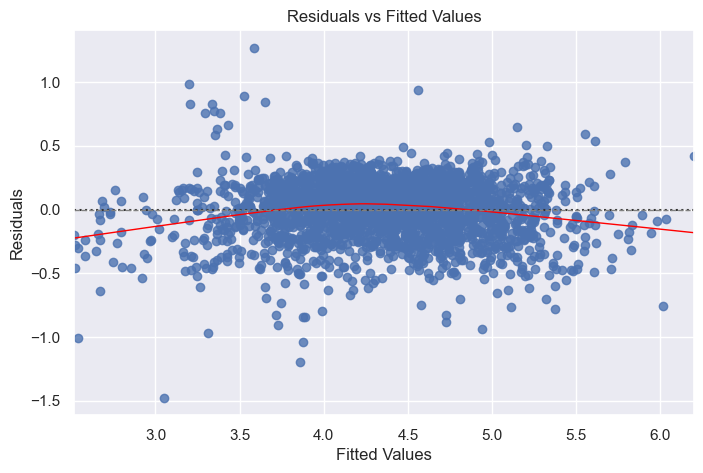

```python
plt.figure(figsize=(8, 5))
sns.residplot(x=df_pred["Fitted Values"], y=df_pred["Residuals"],
              lowess=True, line_kws={'color': 'red', 'lw': 1})
plt.axhline(0, color='gray', linestyle='--', lw=1)
plt.xlabel("Fitted Values")
plt.ylabel("Residuals")
plt.title("Residuals vs Fitted Values")
plt.show()
```

### Test for Linearity and Independence of Residuals

To check the assumptions of **linearity** and **independence**, I plotted the residuals vs. fitted values.

**Conclusion**: The model satisfies the assumptions of linearity and independence of errors.

### TEST FOR NORMALITY

- We will test for normality by checking the distribution of residuals, by checking the Q-Q plot of residuals, and by using the Shapiro-Wilk test.
- If the residuals follow a normal distribution, they will make a straight line plot, otherwise not.
- If the p-value of the Shapiro-Wilk test is greater than 0.05, we can say the residuals are normally distributed.

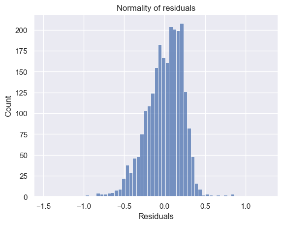

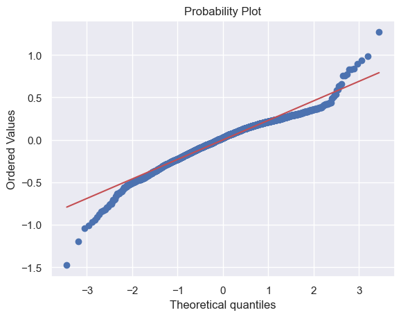

```
ShapiroResult(statistic=0.9649642705917358, pvalue=8.772814053018857e-24)
```

```python
# Histogram of residuals
sns.histplot(data=df_pred, x="Residuals")
plt.title("Normality of residuals")
plt.show()

# Q-Q plot
import pylab
import scipy.stats as stats

stats.probplot(df_pred["Residuals"], dist="norm", plot=pylab)
plt.show()

# Shapiro-Wilk test
stats.shapiro(df_pred["Residuals"])
```

### Test for Normality of Residuals

I assessed the normality of residuals using three methods:

#### Interpretation:

- The **very low p-value** suggests a statistically significant deviation from normality.
- However, with a **large sample size (n = 2417)**, even small deviations can result in a low p-value.
- Visual inspection indicates that residuals are **approximately normal**, which is generally acceptable in linear regression.

**Conclusion**: While the residuals are not perfectly normal, their distribution is close enough to satisfy the assumption for linear regression in this context.

### Test for Homescedastiscity

- We will test for homoscedasticity by using the goldfeldquandt test.
- If we get a p-value greater than 0.05, we can say that the residuals are homoscedastic. Otherwise, they are heteroscedastic.

```python
df_pred["Fitted Values"]
```

```
1744    4.335339
3141    3.913854
1233    4.424896
3046    3.879355
2649    3.895654
          ...
1095    4.251883
1130    4.378004
1294    4.586517
860     4.011221
3174    4.305417
Name: Fitted Values, Length: 2417, dtype: float64
```

```python
import statsmodels.stats.api as sms
from statsmodels.compat import lzip

name = ["F statistic", "p-value"]
#test = sms.het_goldfeldquandt(df_pred["Residuals"], df_pred["Fitted Values"])
test = sms.het_goldfeldquandt(y_train, x_train3)
lzip(name, test)
```

```
[('F statistic', 0.9641994491048725), ('p-value', 0.7355166210796139)]
```

### Test for Homoscedasticity (Goldfeld–Quandt Test)

I tested for **homoscedasticity**, which refers to the assumption that the variance of the residuals is constant across all levels of the independent variables.

#### Method:

- Used the **Goldfeld–Quandt test**.
- **Null Hypothesis (H₀)**: Residuals have constant variance (homoscedastic).
- **Alternative Hypothesis (H₁)**: Residuals have non-constant variance (heteroscedastic).

#### Results:

- **F-statistic**: 0.9642
- **p-value**: 0.7355

#### Interpretation:

- Since the **p-value > 0.05**, we **fail to reject the null hypothesis**.
- This confirms that the residuals are **homoscedastic**, fulfilling this assumption of linear regression.

```python
# Fit the final model using selected features
olsmodel_final = sm.OLS(y_train, x_train3).fit()
print(olsmodel_final.summary())
```

```
                              OLS Regression Results
=================================================================================
Dep. Variable:     normalized_used_price   R-squared:                       0.844
Model:                               OLS   Adj. R-squared:                  0.843
Method:                    Least Squares   F-statistic:                     924.9
Date:                   Sun, 11 May 2025   Prob (F-statistic):               0.00
Time:                           20:01:15   Log-Likelihood:                 83.055
No. Observations:                   2417   AIC:                            -136.1
Df Residuals:                       2402   BIC:                            -49.26
Df Model:                             14
Covariance Type:               nonrobust
========================================================================================
                           coef    std err          t      P>|t|      [0.025      0.975]
----------------------------------------------------------------------------------------
const                    1.7635      0.068     25.886      0.000       1.630       1.897
main_camera_mp           0.0233      0.001     16.053      0.000       0.020       0.026
selfie_camera_mp         0.0127      0.001     11.252      0.000       0.010       0.015
int_memory               0.0002   6.75e-05      2.594      0.010    4.27e-05       0.000
ram                      0.0332      0.005      6.273      0.000       0.023       0.044
weight                   0.0016   5.98e-05     27.505      0.000       0.002       0.002
normalized_new_price     0.4168      0.011     37.284      0.000       0.395       0.439
years_since_release     -0.0291      0.003     -8.394      0.000      -0.036      -0.022
has_selfie_camera       -0.2125      0.054     -3.924      0.000      -0.319      -0.106
brand_name_Asus          0.0601      0.026      2.288      0.022       0.009       0.112
brand_name_Celkon       -0.1752      0.054     -3.234      0.001      -0.281      -0.069
brand_name_Xiaomi        0.0846      0.025      3.331      0.001       0.035       0.134
os_Others               -0.2008      0.031     -6.545      0.000      -0.261      -0.141
4g_yes                   0.0485      0.015      3.165      0.002       0.018       0.078
5g_yes                  -0.1047      0.032     -3.282      0.001      -0.167      -0.042
==============================================================================
Omnibus:                      245.075   Durbin-Watson:                   1.993
Prob(Omnibus):                  0.000   Jarque-Bera (JB):              631.875
Skew:                          -0.572   Prob(JB):                    6.17e-138
Kurtosis:                       5.228   Cond. No.                     3.68e+03
==============================================================================

Notes:
[1] Standard Errors assume that the covariance matrix of the errors is correctly specified.
[2] The condition number is large, 3.68e+03. This might indicate that there are
strong multicollinearity or other numerical problems.
```

```python
# Check performance on train set (seen 70% data)
print("Training Performance\n")
olsmodel_final_train_perf = model_performance_regression(olsmodel_final, x_train3, y_train)
olsmodel_final_train_perf
```

```
Training Performance
```

|  | RMSE | MAE | R-squared | Adj. R-squared | MAPE |
| --- | --- | --- | --- | --- | --- |
| 0 | 0.233797 | 0.181551 | 0.84353 | 0.842553 | 4.375921 |

```python
# Check performance on test set (unseen 30% data)
print("Test Performance\n")
olsmodel_final_test_perf = model_performance_regression(olsmodel_final, x_test3, y_test)
olsmodel_final_test_perf
```

```
Test Performance
```

|  | RMSE | MAE | R-squared | Adj. R-squared | MAPE |
| --- | --- | --- | --- | --- | --- |
| 0 | 0.240717 | 0.189812 | 0.829843 | 0.827343 | 4.547026 |

### Final Model Summary

The final model was developed after addressing multicollinearity (using VIF) and removing high p-value predictors.

A total of 14 predictors were retained, all statistically significant (p-value < 0.05).

Key insights:

- **normalized_new_price** (coef = 0.4168) is the strongest predictor, indicating that the original retail price has a large positive effect on used phone price.
- Features like **weight**, **main_camera_mp**, and **ram** have positive influence on used price.
- Features such as **years_since_release** and **has_selfie_camera** show negative associations.
- High and consistent R-squared values between training and testing data suggest a good generalization of the model.
- MAPE < 5% confirms excellent predictive accuracy.
- No signs of overfitting detected.

Conclusion

And is ready to support business decisions related to used device pricing.

## Actionable Insights and Recommendations

### Business Recommendations Based on Final Model

Based on the insights from the final linear regression model, the following business recommendations are suggested for ReCell:

#### 1. **Focus on Devices with Higher New Price**

- Devices with higher normalized new prices tend to retain more of their value in the used market.
- **Strategy:** Prioritize sourcing and marketing flagship and premium models for better resale margins.

#### 2. **Promote Devices with Strong Camera Capabilities**

- Both **main camera** and **selfie camera megapixels** significantly impact used price.
- **Strategy:** Highlight camera specifications prominently in listings and promotional material, especially for selfie-centric devices.

#### 3. **Target Devices with Higher RAM and Storage**

- Devices with **higher RAM** and **internal memory** correlate with better resale value.
- **Strategy:** Focus on acquiring mid-to-high range configurations (e.g., 6GB+ RAM, 128GB+ storage) as they command higher prices.

#### 5. **Account for Age of Device**

- Older devices (more years since release) negatively impact resale price.
- **Strategy:** Implement dynamic pricing strategies to aggressively discount and clear older inventory.

#### 6. **Operating System Matters**

- Devices with operating systems categorized as “Others” (non-Android/iOS) are priced significantly lower.
- **Strategy:** Avoid sourcing obscure OS devices; focus on mainstream platforms to ensure resale value.

#### 7. **4G and 5G Trends**

- **4G support** slightly boosts price; however, **5G support** shows a small **negative impact**, possibly due to limited current demand or higher expectations.
- **Strategy:** Monitor market trends. As 5G adoption grows, this dynamic may shift—adjust sourcing accordingly.

These recommendations can guide procurement, pricing, and marketing strategies to improve profitability and customer satisfaction in ReCell’s used device marketplace.